# Homework 3 DS 303

Alexis Maldonado

9/10/2023

1.a

```r
mlrmodel <- lm(Sales ~ CompPrice + Income + Advertising + Population + Price + Age + Education + Urban + US, data = Carseats)
summary(mlrmodel)
```

```
##
## Call:
## lm(formula = Sales ~ CompPrice + Income + Advertising + Population +
##     Price + Age + Education + Urban + US, data = Carseats)
##
## Residuals:
##    Min     1Q Median     3Q    Max
## -5.026 -1.341 -0.187  1.141  4.867
##
## Coefficients:
##               Estimate Std. Error t value Pr(>|t|)
## (Intercept)  7.8243876  1.1298792   6.925 1.81e-11 ***
## CompPrice    0.0942545  0.0078637  11.986  < 2e-16 ***
## Income       0.0130501  0.0034908   3.738 0.000213 ***
## Advertising  0.1369399  0.0210394   6.509 2.33e-10 ***
## Population  -0.0002007  0.0007010  -0.286 0.774780
## Price       -0.0924395  0.0050621 -18.261  < 2e-16 ***
## Age         -0.0447919  0.0060226  -7.437 6.59e-13 ***
## Education   -0.0423034  0.0373738  -1.132 0.258371
## UrbanYes    -0.1559036  0.2133519  -0.731 0.465380
## USYes       -0.1062926  0.2832192  -0.375 0.707640
## ---
## Signif. codes:  0 '***' 0.001 '**' 0.01 '*' 0.05 '.' 0.1 ' ' 1
##
## Residual standard error: 1.932 on 390 degrees of freedom
## Multiple R-squared:  0.5425, Adjusted R-squared:  0.5319
## F-statistic: 51.38 on 9 and 390 DF,  p-value: < 2.2e-16
```

Chosen regression coefficeint: Population H0: Bpop = 0 H1: Bpop != 0

Test Static: -0.286

P-Value: 0.774780

Conclusion: Since 0.77 is not smaller than 0.05 we do not reject H0, meaning that we do not have evidence that Population is significally different from 0, at sigificance level 0.05.

1.b

```r
summary(mlrmodel)$sigma
```

```
## [1] 1.932204
```

Residual standard error: 1.932. This value represent the average distance we are from the mean.

1.c

```r
coef(mlrmodel)["Advertising"]
```

```
## Advertising
##   0.1369399
```

Advertising estimate 0.1369399 can be interpreted as the average change in Y with a 1 unit change in X, holding all other predictors constant.

1.d

```r
reducedmodel <- lm(Sales ~ CompPrice + Income + Advertising + Population + Price + Age + Education + Urban, data = Carseats)

sum(residuals(mlrmodel)^2)
```

```
## [1] 1456.031
```

```r
sum(residuals(reducedmodel)^2)
```

```
## [1] 1456.557
```

full model = 1456.031 reduced model = 1456.557

1.e

```r
summary(mlrmodel)$df
```

```
## [1]  10 390  10
```

```r
summary(reducedmodel)$df
```

```
## [1]   9 391   9
```

```r
((1456.557 - 1456.031)/(391-390)) / (1456.031/ 390)
```

```
## [1] 0.1408899
```

```r
summary(mlrmodel)
```

```
##
## Call:
## lm(formula = Sales ~ CompPrice + Income + Advertising + Population +
##     Price + Age + Education + Urban + US, data = Carseats)
##
## Residuals:
##    Min     1Q Median     3Q    Max
## -5.026 -1.341 -0.187  1.141  4.867
##
## Coefficients:
##               Estimate Std. Error t value Pr(>|t|)
## (Intercept)  7.8243876  1.1298792   6.925 1.81e-11 ***
## CompPrice    0.0942545  0.0078637  11.986  < 2e-16 ***
## Income       0.0130501  0.0034908   3.738 0.000213 ***
## Advertising  0.1369399  0.0210394   6.509 2.33e-10 ***
## Population  -0.0002007  0.0007010  -0.286 0.774780
## Price       -0.0924395  0.0050621 -18.261  < 2e-16 ***
## Age         -0.0447919  0.0060226  -7.437 6.59e-13 ***
## Education   -0.0423034  0.0373738  -1.132 0.258371
## UrbanYes    -0.1559036  0.2133519  -0.731 0.465380
## USYes       -0.1062926  0.2832192  -0.375 0.707640
## ---
## Signif. codes:  0 '***' 0.001 '**' 0.01 '*' 0.05 '.' 0.1 ' ' 1
##
## Residual standard error: 1.932 on 390 degrees of freedom
## Multiple R-squared:  0.5425, Adjusted R-squared:  0.5319
## F-statistic: 51.38 on 9 and 390 DF,  p-value: < 2.2e-16
```

H0: all predictors are equal H1: atleast one predictor != 0

F-test: 51.38

Null Distribution: F 9,390

P-Value: 2.2e-16

Conclusion: We reject H0: we find evidence of a relationship between Y and at least one of the predictors, at significance level 0.05.

1.f

```r
mean(Carseats$CompPrice)
```

```
## [1] 124.975
```

```r
mean(Carseats$Income)
```

```
## [1] 68.6575
```

```r
summary(mlrmodel)
```

```
##
## Call:
## lm(formula = Sales ~ CompPrice + Income + Advertising + Population +
##     Price + Age + Education + Urban + US, data = Carseats)
##
## Residuals:
##    Min     1Q Median     3Q    Max
## -5.026 -1.341 -0.187  1.141  4.867
##
## Coefficients:
##               Estimate Std. Error t value Pr(>|t|)
## (Intercept)  7.8243876  1.1298792   6.925 1.81e-11 ***
## CompPrice    0.0942545  0.0078637  11.986  < 2e-16 ***
## Income       0.0130501  0.0034908   3.738 0.000213 ***
## Advertising  0.1369399  0.0210394   6.509 2.33e-10 ***
## Population  -0.0002007  0.0007010  -0.286 0.774780
## Price       -0.0924395  0.0050621 -18.261  < 2e-16 ***
## Age         -0.0447919  0.0060226  -7.437 6.59e-13 ***
## Education   -0.0423034  0.0373738  -1.132 0.258371
## UrbanYes    -0.1559036  0.2133519  -0.731 0.465380
## USYes       -0.1062926  0.2832192  -0.375 0.707640
## ---
## Signif. codes:  0 '***' 0.001 '**' 0.01 '*' 0.05 '.' 0.1 ' ' 1
##
## Residual standard error: 1.932 on 390 degrees of freedom
## Multiple R-squared:  0.5425, Adjusted R-squared:  0.5319
## F-statistic: 51.38 on 9 and 390 DF,  p-value: < 2.2e-16
```

```r
Xh = data.frame(CompPrice = 124.97, Income = 68.65, Advertising = 15, Population = 500, Price = 50, Age = 30, Education = 10, Urban = "Yes", US = "Yes")
predict(mlrmodel,newdata=Xh,interval='confidence',level=0.95)
```

```
##        fit      lwr      upr
## 1 15.80203 14.91442 16.68965
```

15.80 is the estimate. from the confidence interval we get a fit of 15.80203, lower interval of 14.91442, and upper of 16.68965

1.g

```r
ans = 7.8243876 + 124.975 * (0.0942545) + 68.6575 * (0.0130501) + 15 * (0.1369399) + 500 * (-0.0002007) + 50 * (-0.0924395) + 30 * (-0.0447919) + 10 * (-0.0423034) + 1 * (-0.1559036) + 1 * (-0.1062926)
ans
```

```
## [1] 15.80262
```

```r
predict(mlrmodel, newdata=Xh,interval='prediction',level=0.95)
```

```
##        fit      lwr      upr
## 1 15.80203 11.90087 19.70319
```

15.80 is the prediction from the prediction interval we get a fit of 15.80203, lower interval of 11.90087, and upper of 19.70319. 1.h

```r
Xh1 = data.frame(CompPrice = 124.97, Income = 68.65, Advertising = 15, Population = 500, Price = 450, Age = 30, Education = 10, Urban = "Yes", US = "Yes")
predict(mlrmodel, newdata=Xh1,interval='prediction',level=0.95)
```

```
##         fit       lwr       upr
## 1 -21.17377 -26.22631 -16.12124
```

the prediction is -21.17377, which does not make sense. One of the limitations must be around price since by going to the extreme price it completely over took the outcome of the value

2.a We should expect to make m /α type 1 errors.

2.b P(V ≥ 1) = 1 - (1 - α)^m

2.c A setting where this could be a real problem could be when your working with medicine and all the other variables are making the drug look better than it really is.

2.d Yes is makes sense beacuse your lowering the amount of false positives. 1 - [(1 - α/m)^m]

2.e

```r
x = matrix(NA,1000,200)

for(i in 1:200){
    x[,i] = rnorm(1000)
 }

beta0 = 1
beta1 = 2
beta2 = 3
beta3 = 4
beta4 = 5
beta5 = 6

error = rnorm(1000,0,1)
y = beta0 + beta1*x[,1] + beta2*x[,2] + beta3*x[,3] + beta4*x[,4] + beta5*x[,5] + error

data = as.data.frame(cbind(y,x))

fit = lm(y~.,data=data)

p_values = summary(fit)$coefficients[,4]
length(which(p_values<0.05/200))
```

```
## [1] 6
```

2.f Although it does lower the predictors one thing that could back firing is that you could miss important predictors that didnt make the cut.

3.a 1. Relationship between Y and X is linear 2. E (e) = 0 3. Var(e) = σ2 4. e’s are uncorrelated

3.b True, when fitting a multiple linear regression we assume that random error is 0.

3.c True, the out does show us individual p-value based on the information given while assuming the random error are normally distributed.

3.d Its not sufficient to check every pairwaise scatterplot between the 2 because visually they arent as reliable as other and arent always able to show us the whole picture at time, using other graphs and/or techniques would be better to fully grasps the relationship between the two.

3.e

```r
m1 = lm(mpg~horsepower,data=Auto)
summary(m1)
```

```
##
## Call:
## lm(formula = mpg ~ horsepower, data = Auto)
##
## Residuals:
##      Min       1Q   Median       3Q      Max
## -13.5710  -3.2592  -0.3435   2.7630  16.9240
##
## Coefficients:
##              Estimate Std. Error t value Pr(>|t|)
## (Intercept) 39.935861   0.717499   55.66   <2e-16 ***
## horsepower  -0.157845   0.006446  -24.49   <2e-16 ***
## ---
## Signif. codes:  0 '***' 0.001 '**' 0.01 '*' 0.05 '.' 0.1 ' ' 1
##
## Residual standard error: 4.906 on 390 degrees of freedom
## Multiple R-squared:  0.6059, Adjusted R-squared:  0.6049
## F-statistic: 599.7 on 1 and 390 DF,  p-value: < 2.2e-16
```

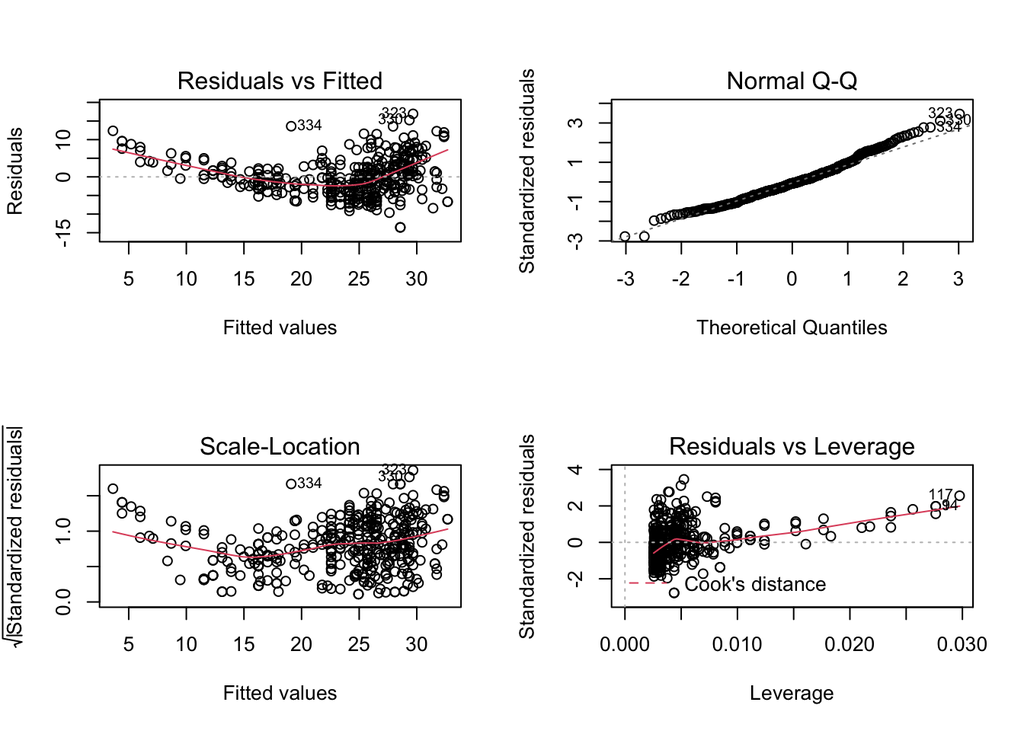

```r
par(mfrow=c(2,2))
plot(m1)
```

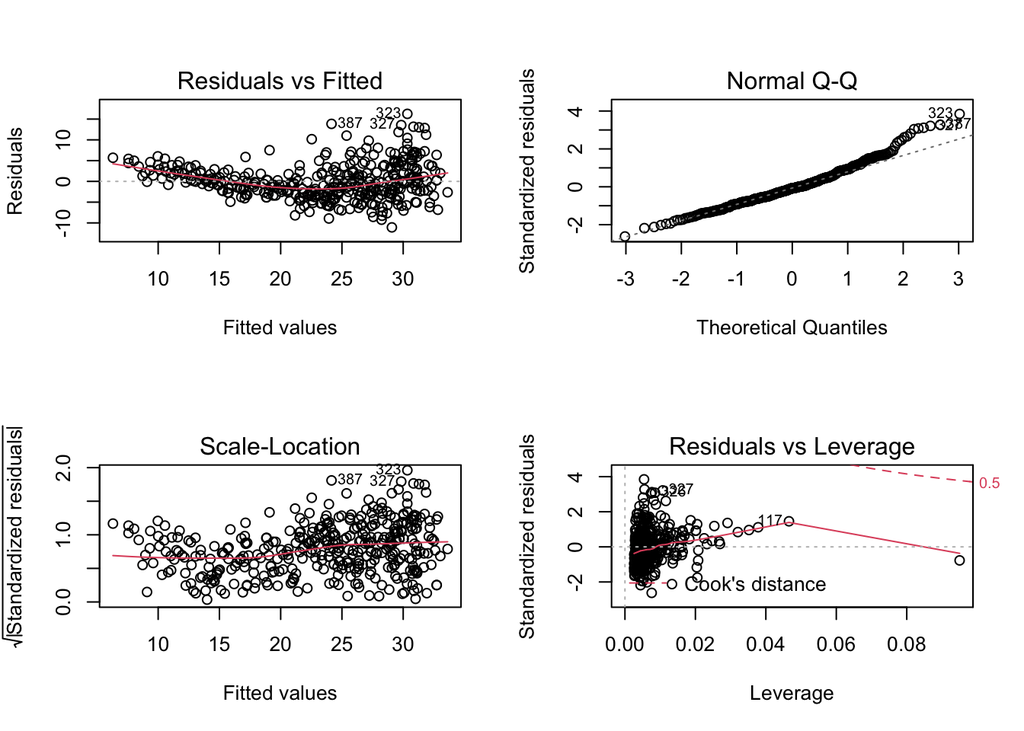

```r
m2 = lm(mpg~ weight + horsepower,data=Auto)
plot(m2)
```

```r
BIC(m1)
```

```
## [1] 2375.237
```

```r
BIC(m2)
```

```
## [1] 2265.89
```

By adding another variable we are able to bring down the BIC for m2 being 2265.89 compared to 2375.237 the BIC for m1. So it is an improvemnt.